# Monitoramento Blend4

## Execução

```
Última execução: 06/10/2026 10:01:54 -03
```

## Imports

## Diretório

## Base Blend4 em Produção

## Gráficos

# Uniproponente

# Primeira Semana

Acompanhamento diário do Mix de Modelos que vemos dos nossos leads.

```
Período: 2026-09-28 00:00:00 → 2026-10-05 00:00:00
Volume total: 36,970
```

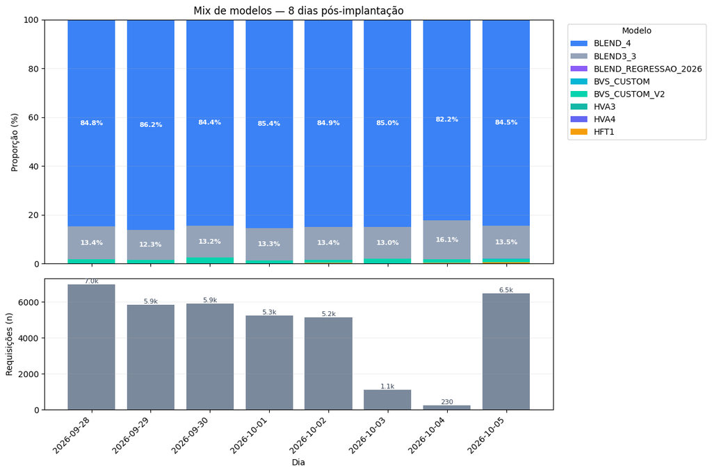

## Semanal

```
Semanas: 6 | Volume: 153,339
Período: 2026-08-30 00:00:00 → 2026-10-05 00:00:00
```

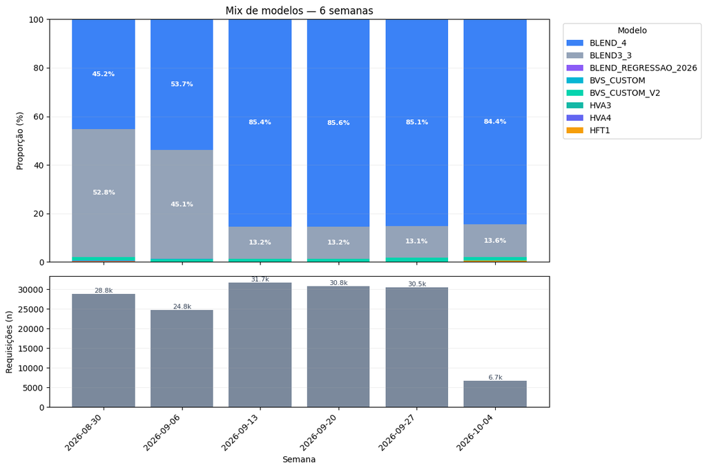

## Mix de Rating BLEND4 vs. BLEND3

Esse Mix de Rating não é exatamente o Mix de Rating visto na tabela do Funil, pois estamos avaliando o público que tem score Blend4, ou seja excluindo o público E-BVS, negado diretamente.

```
['A', 'B', 'C', 'D', 'E', 'N']
```

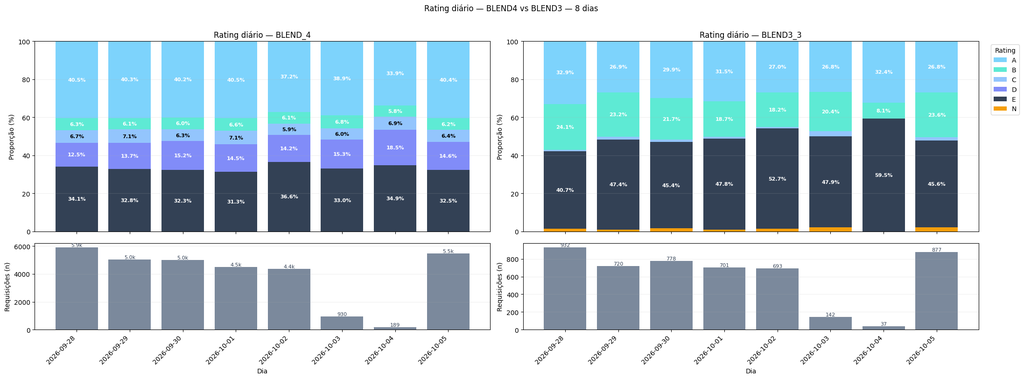

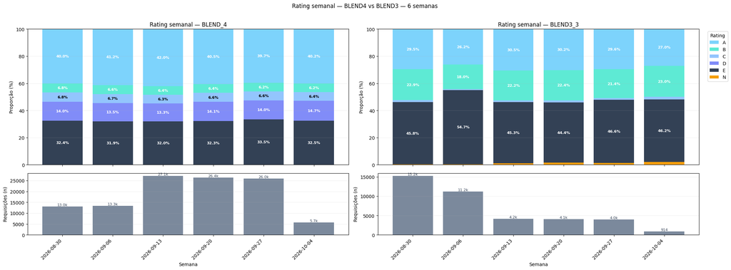

# Comparação: Score CR vs. Score Manual

Nessa secção queremos entender se não há nenhum erro de escoragem no Modelo BLEND4, ou seja, se score que está na CR é o mesmo que o escorado manualmente.

## Scores Blend4

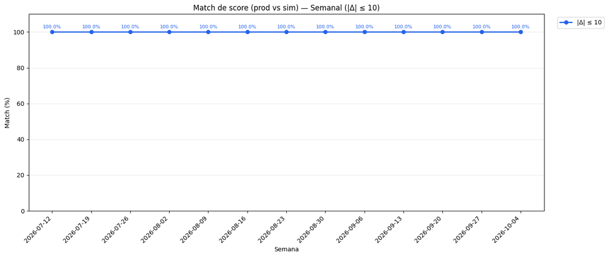

## Ratings

No caos dos Ratings, o que queremos é entender se em dias que houve alguma falha de escoragem, se houve alteração no Mix.

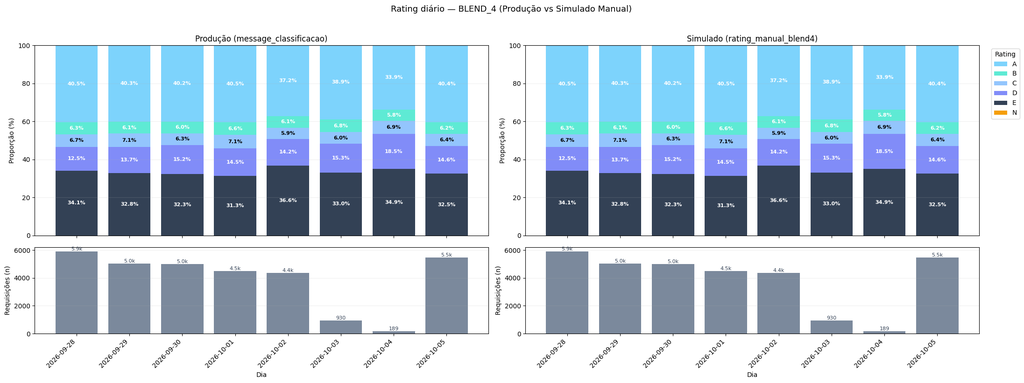

```
BLEND_4
```

| rating_manual_blend4 message_classificacao | A | B | C | D | E | All |
| --- | --- | --- | --- | --- | --- | --- |
| A | 12525 | 0 | 0 | 0 | 0 | 12525 |
| B | 0 | 1952 | 0 | 0 | 0 | 1952 |
| C | 0 | 0 | 2058 | 0 | 0 | 2058 |
| D | 0 | 0 | 0 | 4433 | 0 | 4433 |
| E | 0 | 0 | 0 | 0 | 10445 | 10445 |
| All | 12525 | 1952 | 2058 | 4433 | 10445 | 31413 |

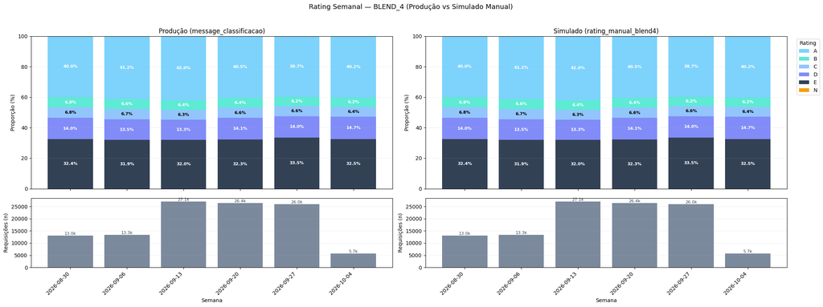

```
BLEND_4
```

| rating_manual_blend4 message_classificacao | A | B | C | D | E | All |
| --- | --- | --- | --- | --- | --- | --- |
| A | 45336 | 0 | 0 | 0 | 0 | 45336 |
| B | 0 | 7172 | 0 | 0 | 0 | 7172 |
| C | 0 | 0 | 7285 | 0 | 0 | 7285 |
| D | 0 | 0 | 0 | 15406 | 0 | 15406 |
| E | 0 | 0 | 0 | 0 | 36198 | 36198 |
| All | 45336 | 7172 | 7285 | 15406 | 36198 | 111397 |

## PSI das Variáveis

```
Target day: 2026-10-05
```

|  | variable | comparison | psi | status | n_actual | psi_oot_vs_train_ref | psi_test_vs_train_ref |
| --- | --- | --- | --- | --- | --- | --- | --- |
| 0 | city_pc4_mais_100_contratos__pc_categorias | production_vs_train | 0.161648 | moderate | 5478 | 0.054503 | 0.000085 |
| 1 | income_commitment | production_vs_train | 0.056302 | stable | 5478 | 0.000865 | 0.000048 |
| 2 | SERASA_CHSV5 | production_vs_train | 0.028347 | stable | 5478 | 0.020552 | 0.000130 |
| 3 | pred_blend4_1_to_score | production_vs_train | 0.017662 | stable | 5478 | 0.023760 | 0.000040 |
| 4 | score_proposto__bvs | production_vs_train | 0.014899 | stable | 5478 | 0.010233 | 0.000116 |
| 5 | city_pc4_mais_100_contratos__pc_categorias_is_... | production_vs_train | 0.009288 | stable | 5478 | 0.000236 | 0.000011 |
| 6 | age | production_vs_train | 0.007448 | stable | 5478 | 0.001148 | 0.000071 |
| 7 | qtde_restricoes__consulta_realizada | production_vs_train | 0.007052 | stable | 5478 | 0.023589 | 0.000028 |
| 8 | property_type | production_vs_train | 0.004098 | stable | 5478 | 0.002975 | 0.000004 |
| 9 | agency_pc4_mais_100_contratos__pc_categorias_i... | production_vs_train | 0.002059 | stable | 5478 | 0.001303 | 0.000000 |
| 10 | flag_teve_boleto_atrasado__contratos_anteriores | production_vs_train | 0.000702 | stable | 5478 | 0.000237 | 0.000002 |
| 11 | flag_tem__contratos_anteriores | production_vs_train | 0.000662 | stable | 5478 | 0.000000 | 0.000002 |
| 12 | agency_pc4_mais_100_contratos__pc_categorias | production_vs_train | 0.000009 | stable | 5478 | 0.005090 | 0.000026 |

```
Target Week == 2026-09-27 (Semana Anterior Completa)
```

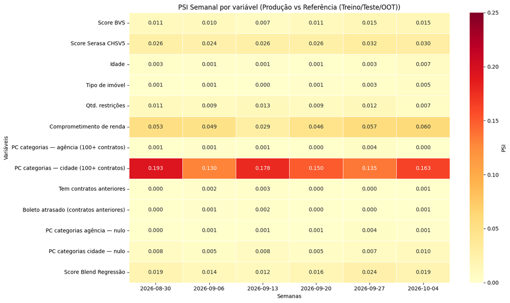

## PSI Semanal W-1 (Última Semana Completa)

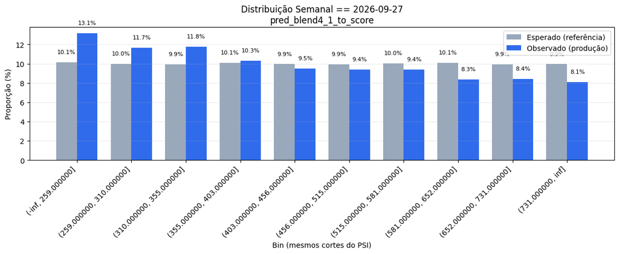

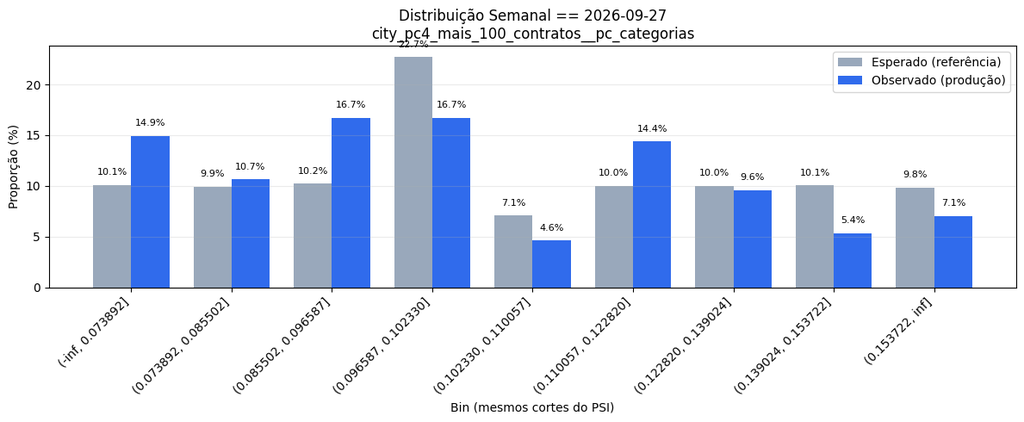

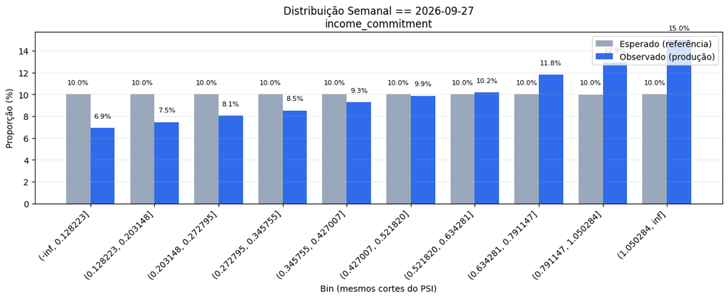

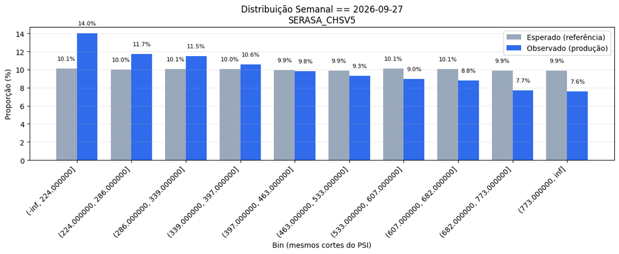

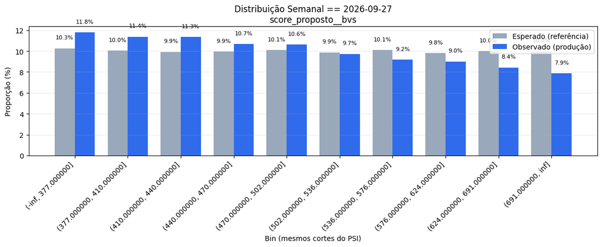

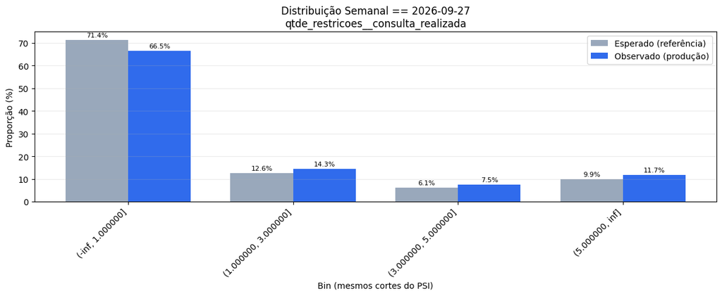

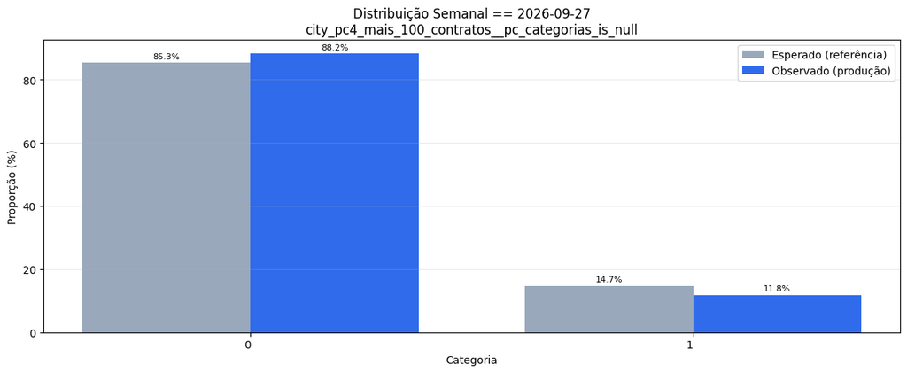

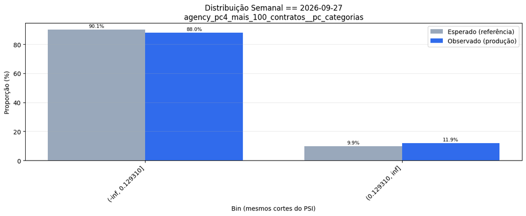

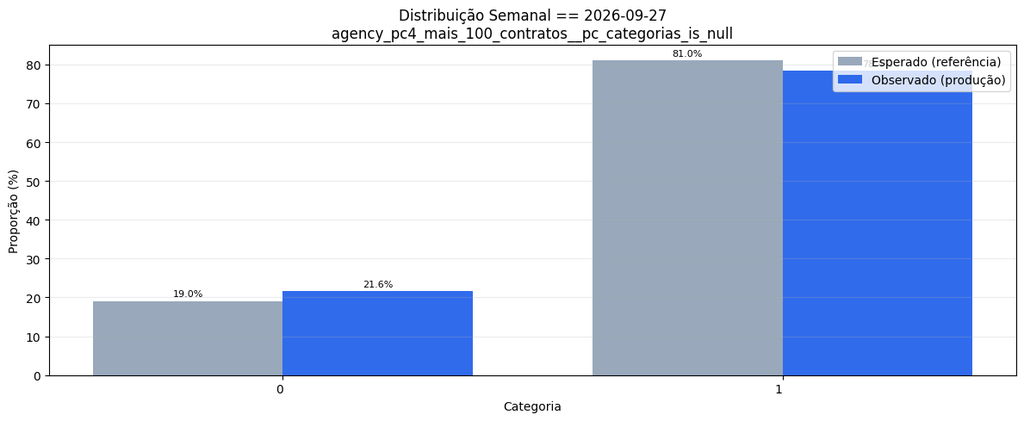

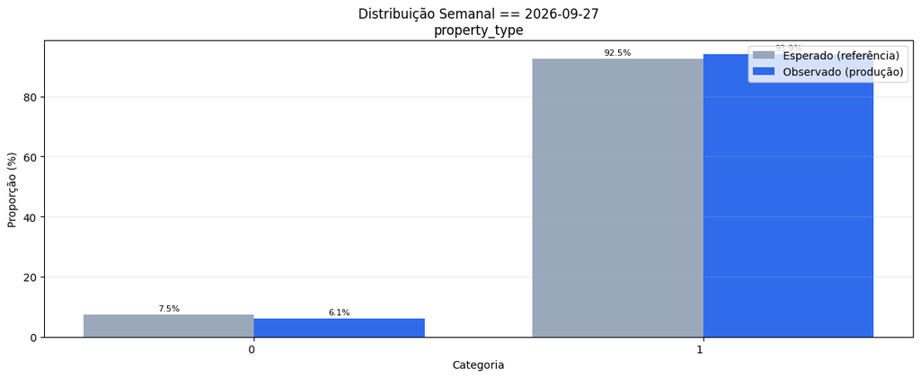

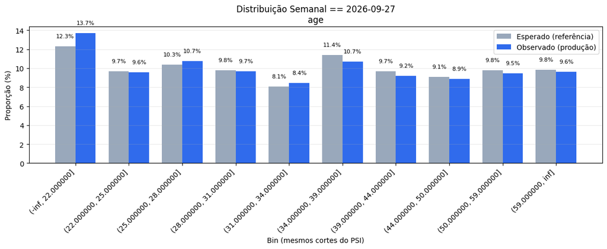

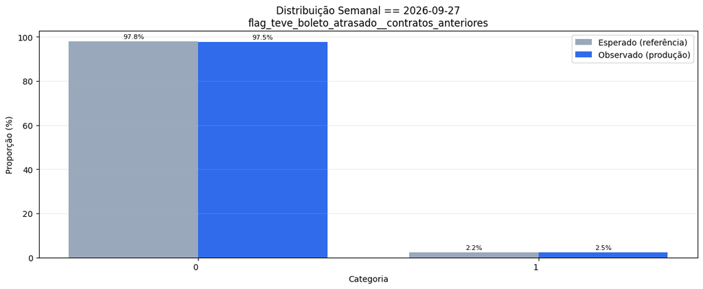

[1 more figures not shown]

# Variáveis: Acompanhamento Histórico

```
Semanas completas: ['2026-08-30', '2026-09-06', '2026-09-13', '2026-09-20', '2026-09-27']
```

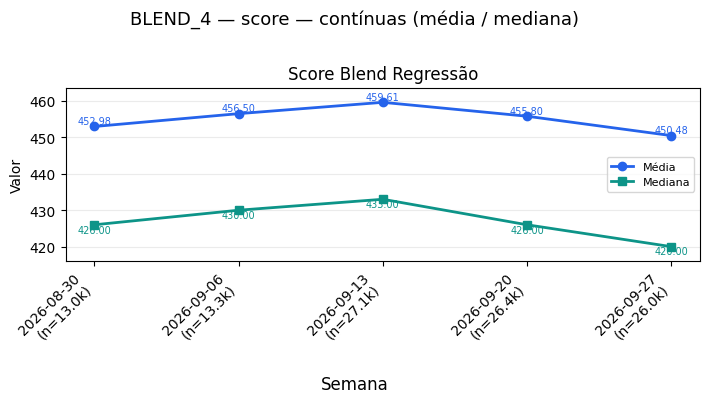

```
[skip] Sem estatísticas binárias para plotar.
```

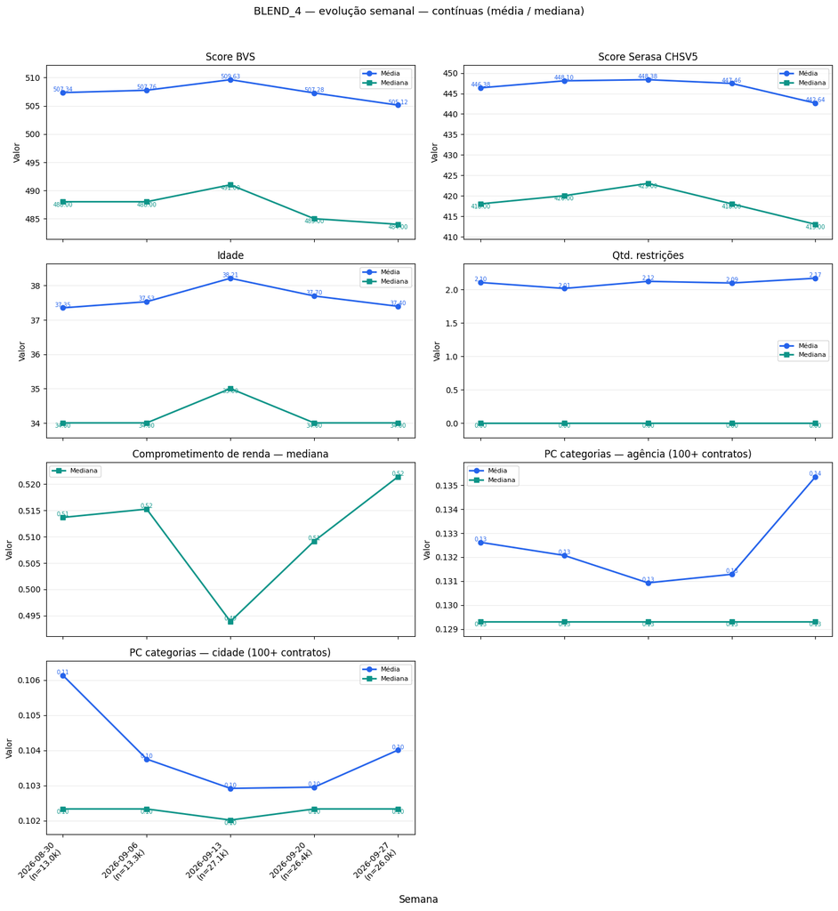

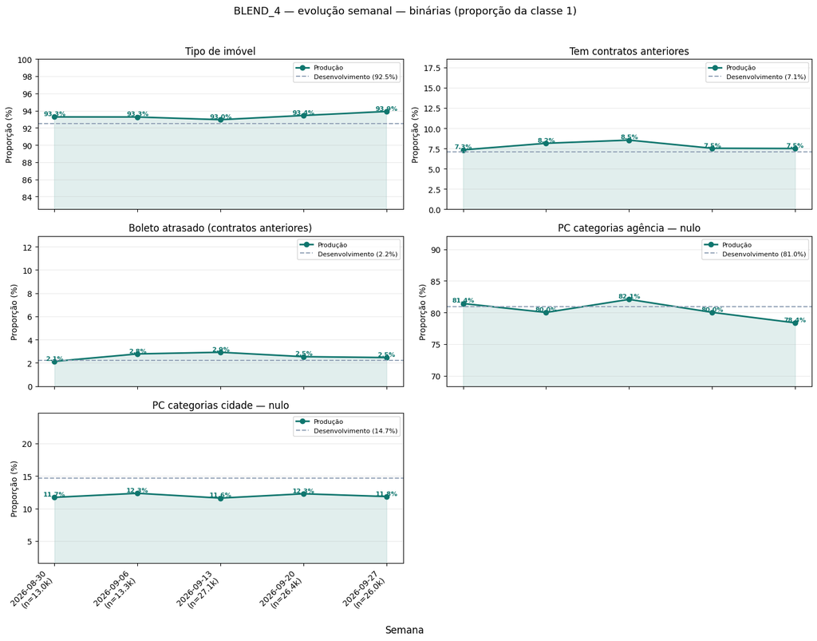

```
Contínuas — média
```

| year_week variable | 2026-08-30 | 2026-09-06 | 2026-09-13 | 2026-09-20 | 2026-09-27 |
| --- | --- | --- | --- | --- | --- |
| Score BVS | 507.344 | 507.759 | 509.633 | 507.276 | 505.123 |
| Score Serasa CHSV5 | 446.380 | 448.095 | 448.377 | 447.463 | 442.641 |
| Idade | 37.352 | 37.530 | 38.213 | 37.697 | 37.396 |
| Qtd. restrições | 2.103 | 2.013 | 2.120 | 2.095 | 2.166 |
| Comprometimento de renda | 4701.388 | 8.852 | 0.616 | 0.706 | 1.752 |
| PC categorias — agência (100+ contratos) | 0.133 | 0.132 | 0.131 | 0.131 | 0.135 |
| PC categorias — cidade (100+ contratos) | 0.106 | 0.104 | 0.103 | 0.103 | 0.104 |

```
Contínuas — mediana
```

| year_week variable | 2026-08-30 | 2026-09-06 | 2026-09-13 | 2026-09-20 | 2026-09-27 |
| --- | --- | --- | --- | --- | --- |
| Score BVS | 488.000 | 488.000 | 491.000 | 485.000 | 484.000 |
| Score Serasa CHSV5 | 418.000 | 420.000 | 423.000 | 418.000 | 413.000 |
| Idade | 34.000 | 34.000 | 35.000 | 34.000 | 34.000 |
| Qtd. restrições | 0.000 | 0.000 | 0.000 | 0.000 | 0.000 |
| Comprometimento de renda | 0.514 | 0.515 | 0.494 | 0.509 | 0.521 |
| PC categorias — agência (100+ contratos) | 0.129 | 0.129 | 0.129 | 0.129 | 0.129 |
| PC categorias — cidade (100+ contratos) | 0.102 | 0.102 | 0.102 | 0.102 | 0.102 |

```
Binárias — proporção da classe 1 (%)
```

| year_week variable | 2026-08-30 | 2026-09-06 | 2026-09-13 | 2026-09-20 | 2026-09-27 |
| --- | --- | --- | --- | --- | --- |
| Tipo de imóvel | 93.3 | 93.3 | 93.0 | 93.4 | 93.9 |
| Tem contratos anteriores | 7.3 | 8.2 | 8.5 | 7.5 | 7.5 |
| Boleto atrasado (contratos anteriores) | 2.1 | 2.8 | 2.9 | 2.5 | 2.5 |
| PC categorias agência — nulo | 81.4 | 80.0 | 82.1 | 80.0 | 78.4 |
| PC categorias cidade — nulo | 11.7 | 12.3 | 11.6 | 12.3 | 11.8 |

# Negado Direto - BVS

Garantir que não estamos comprando SERASA para esse público

Esperado: 10-11% do público OOT reprova direto por BVS (Blend4).

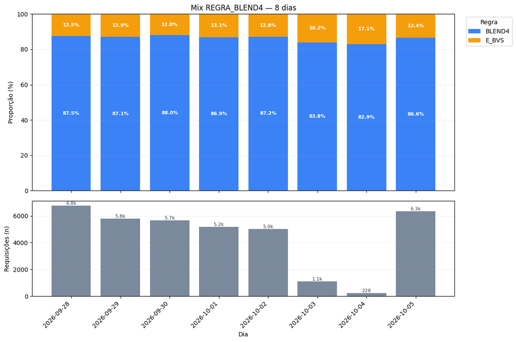

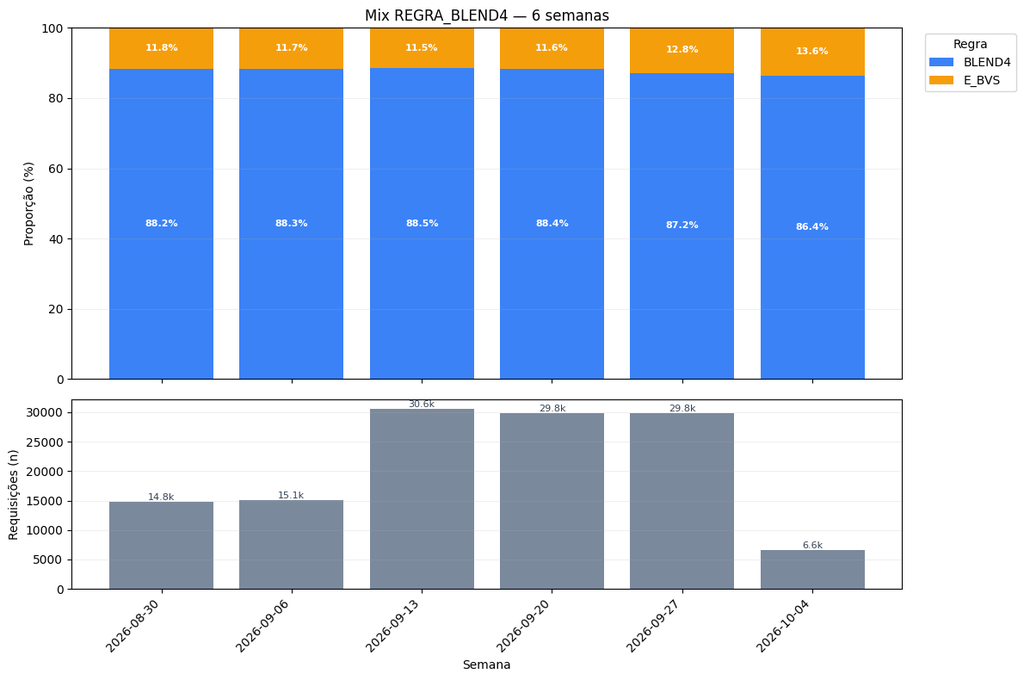

# Falhas (BVS, Serasa)

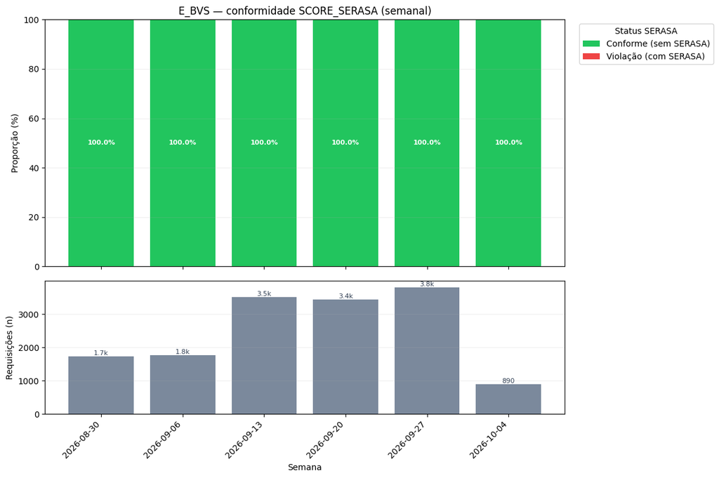

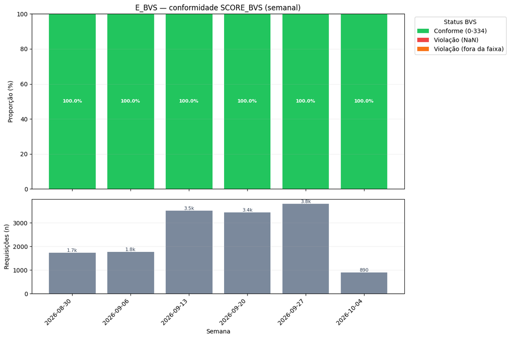

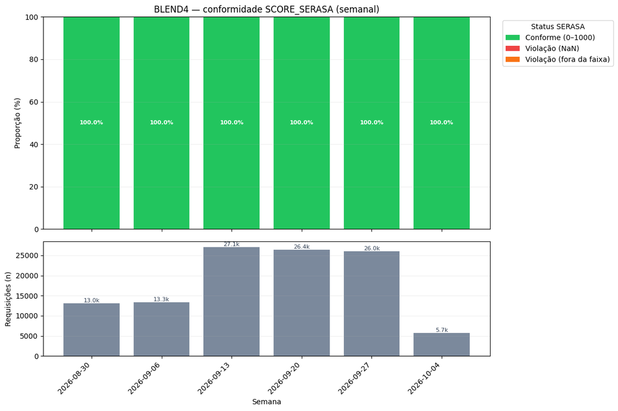

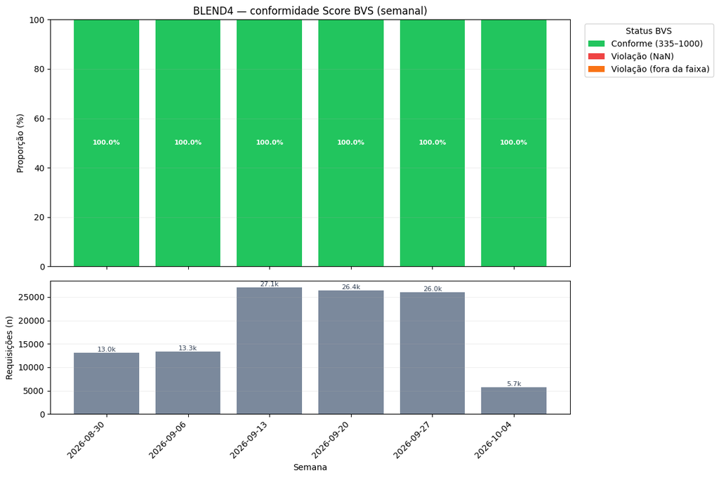

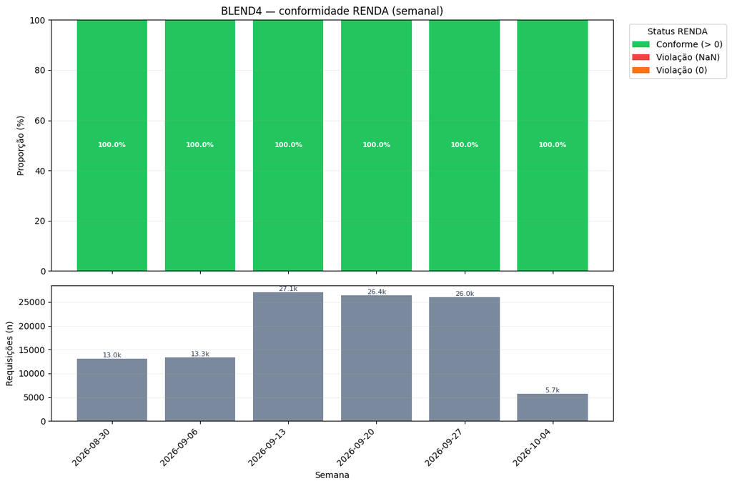